# Tipping Points in the Climate-Social System, Model Documentation

Fran Moore

February 21, 2020

### Model Overview

There are six primary components in the model, with linkages between components shown below. Opinions about climate policy (*Opinion Component*) determine both individual adoption of emissions-reducing behavior (*Adoption Component*) and collective action (*Policy Component*). Adoption and policy togther determine the level of greenhouse gas emissions (*Emissions Component*), which in turn affect the climate system (*Climate Component*).

[interactive chart not shown]

## Opinion Component

Population is divided into three types based on opinion ($Op$) regarding climate policy - Supporting, Neutral, and Opposed (i.e. $\mathbf{Op} = \left[S,N,O\right]$). Movement between adjacent types is determined by two things: a social pressure or persuasive force based on interactions between groups ($Force$) and evidence derived from one’s own experience of weather ($Ev$).

Persuasive forces are governed by two parameters, the persuasive force of neutral on opinionated ($F_{N}$), and the persuasive force of opinionated on neutral ($F_{S,O}$). This allows flexibility to capture a weaker persausive force by people without strong opinons, while limiting the number of paprameters by assuming the persuasive force of supporterns and opposers of climate change policy is equally strong. Therefore, the force matrix describing the persuasive effect felt by each group (rows) from each other group (colums), conditional on encounter is given by:
$$\mathbf{Force} = \left[\begin{array}
{rrr}
0 & F_{N} & F_{S,O} \\
F_{S,O} & 0 & F_{S,O} \\
F_{S,O} & F_{N} & 0
\end{array}\right]$$

The social network defining probability of intereaction for each group (rows) with each other group (columns) is given by:
$$\mathbf{Network_{t}} = \left[\begin{array}
{rrr}
\theta S_{t} & \frac{1-\theta}{2} N_{t} & \frac{1-\theta}{2} O_{t} \\
\frac{1-\theta}{2} S_{t} & \theta N_{t} & \frac{1-\theta}{2} O_{t} \\
\frac{1-\theta}{2} S_{t} & \frac{1-\theta}{2} N_{t} & \theta O_{t}
\end{array}\right]$$

The social force is given by $\mathbf{SocialForce_{t}}=\mathbf{Network_{t}}*\mathbf{Force}$

In addition to social persuasion, transition between opinion groups is also determined directly by the experience of climate chance through the perception of weather anomalies. This evidence effect ($Ev$) is allowed to differ by opinion group (reflecting biassed assilation or other forms of motivated reasoning), can take positive or negative values (depending on whether the perceived weather anomaly is warm or cold), and is scaled by the “evidence effectiveness” parameter, ($\eta$) which determines how strongly perceived weather anomalies affect opinion. More details on how the evidence based on climate change is calculated is in the Cognition Component.

The transition probability matrix, restricting transitions to neighboring opinion groups, is given by:
$$\mathbf{P_{t}}=\left[\begin{array}
{rrr}
(1-(\sum_{j=2,3}SocialForce_{1,j}-\eta*Ev_{1}) & \sum_{j=2,3}SocialForce_{1,j}-\eta*Ev_{1} & 0 \\
SocialForce_{2,1}+\eta*Ev_{2} & (1-(\sum_{j=1,3}SocialForce_{2,j}) & SocialForce_{2,1}-\eta*Ev_{2} \\
0 & \sum_{j=1,2}SocialForce_{3,j}+\eta*Ev_{3} & (1-(\sum_{j=1,2}SocialForce_{3,j}+\eta*Ev_{3})
\end{array}\right]$$

The new distribution of opinion in time t depends on the the previous distribution of opinion and transition probabilities:
$$\mathbf{Op_{t}}=\mathbf{Op_{t-1}}*\mathbf{P_{t}}$$

## Policy Component

Collective policy is summarized by a single value, which can be positive or negative, and can be thought of as the magnitude of the tax on carbon emissions (or subsidy of fossil fuels). Policy is cumulative, with the change in policy each period determined by the distribution of opinion and a single “policy responsiveness” parameter, $\nu$.

If the number of supporters is greater than the number of opposers (i.e. $S_{t}>O_{t}$) the the change in policy in period t is given by:
$$\Delta Policy_{t} =
\begin{cases}
0 & \text{if } \frac{S_{t}}{O_{t}}<\nu\\
(1-N_{t})^{2}*( \frac{S_{t}}{O_{t}}-\nu)^{(1+\frac{1}{\nu})} &\text{otherwise}
\end{cases}$$

The policy responsiveness parameter does two things. Firstly it creates a threshold that majorities of opinion must overcome, before they are able to influence policy. Secondly it affects the rate at which policy responds to larger opinion majorities beyond the threshold. At the lower bound of $\nu=1$, simple majorities are enough to effect change and the rate of change is a quadratic in the size of the majoritiy. As $\nu$ increases, the opinion threshold becomes larger and the rate of increase tends towards linear (i.e. $(1+\frac{1}{\nu})\xrightarrow[\nu \to \infty]{} 1$). The population of people without strong opinions on climate policy ($N_{t}$) creates inertia in the policy response, so that the policy response is smaller if a large fraction of people do not have strong opinions about policy.

The functional form with two values of $\nu$ and two values of $N_{t}$ are given below:

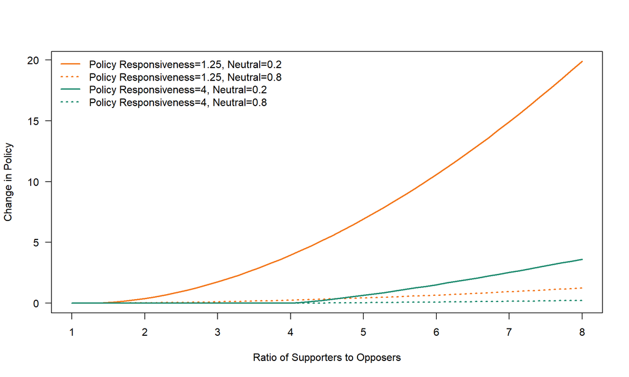

The formulation is symmetric in the opposite case that $O_{t}>S_{t}$, with the change in policy then being negative rather than positive. Policy is limited by an arbitrary maximimum value of 300.

## Adoption Component

Individual behavior to reduce emissions is represented by choice to adopt or not adopt a single sustainable behavior that reduces individual emissions. It can be thought of as a representitive composite of all the actions individuals can take to reduce emissions. The adoption decision is determined by two things: 1) the social norm around adoption / non-adoption determined by the social network for each opinion group and 2) perceived behavioral control, the opposite of adoption costs, which are affected by the total number of adopters, policy, and opinion.

The fraction of adopters within each opinion group is given by the vector $\mathbf A$. The fraction of adopters within the social network of opinion group i is given by:

$$Frac_{i}=\sum_{j=1,2,3} Network_{i,j}*A_{j}$$
The social norm around adoption felt by members of each opinion group depends on the fraction of network adopting and a “norm effectiveness” scaling parameter ($\lambda$) which determines the strength of the social norm effect:
$$Norm_{i}=
\begin{cases}
\lambda *(1-4Frac_{i}+4Frac_{i}^{2}) & \text{if } Frac_{i}>0.5\\
\lambda *(-1+4Frac_{i}-4Frac_{i}^{2}) &\text{if } Frac_{i}<=0.5
\end{cases}$$

This functional form has the desireable properties that $Norm_{i}=0$ for $Frac_{i}=0.5$ and that increases in $Frac_{i}$ have a larger effect on the norm towards the extreme values of 0 and 1. The functional form is shown below for two values of $\lambda$:

[figure not shown]